# Analiza spektralna rynku pracy

Mateusz Jakubczak

14 Lutego 2021

# Pytanie badawcze

### Jaki jest wpływ rynku pracy na rynek nieruchomości

## Źródło danych

Dane pochodzą z serwisu GUS i obejmują zakres od lat 2005 do 2020 w okresach miesięcznych. https://stat.gov.pl/download/gfx/portalinformacyjny/pl/defaultstronaopisowa/1772/1/5/wybrane_miesieczne_wskazniki_makroekonomiczne_cz_i.xlsx

## Analiza spektralna zależności między dynamiką wynagrodzeń a stopy bezrobocia

#### Analiza ta polega na znalezieniu zależności wzrostem bądź spadkiem stopy bezrobocia i jaki ma to wpływ na poziom średniego wynagrodzenia.

Wybrane czynniki to:

1. Przeciętne miesięczne nominalne wynagrodzenie brutto
2. Bezrobotni zarejestrowani
3. Ilość nowo wybudowanych mieszkań

### Ograniczenia wynikające z założeń

1. Agregujemy dane dla całej polski, bez rozróżnień geograficznych. Dlatego jesteśmy w stanie znaleźć tylko najbardziej globalne zależności, które niemusza być prawdzie dla danego regionu.
2. Pomijamy w analizę wiele innych ważnych czynników ekonomicznych, takich jak inflacja czy PKB, które również mogą mieć wpływ na badaną hipotezę.
3. Zmienne te nie są idealnym wskaźnikiem sytuacji na rynku pracy czy rynku nieruchomości, wybrane zostały ze względu na brak dostępnych dokładniejszych danych
4. Ilość nowo wybudowanych słabo oddaje stan rynku nieruchomości, ponieważ jest obciążona przez średnią cenę nieruchomości (traktujemy w ten sam sposób jeden drogi nowoczesne osiedle o dużej wartości gdzie jest tylko kilkadziesiąt mieszkań tak jak budowę bloku z wielkiej płyty z setką mieszkań) ### W samej analizie nie interesują nas same absolutne wartości a ich dynamika. Dlatego liczymy zmianę procentową dla bezrobocia oraz średniego wynagrodzenia.

## Podczas liczenia dynamiki tracimy informacje dla pierwszego miesiąca co wpływa na dalszą analizę spektralną, ponieważ nie mamy pełnych okresów rocznych.

### Rozwiązujemy to poprzez odrzucenie całości danych z pierwszego roku.

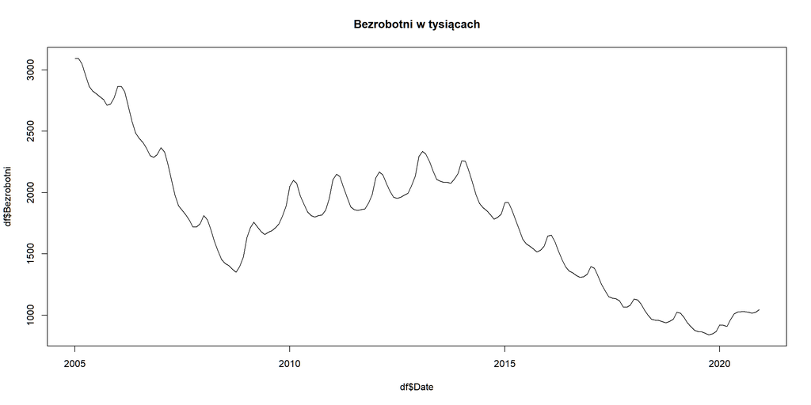

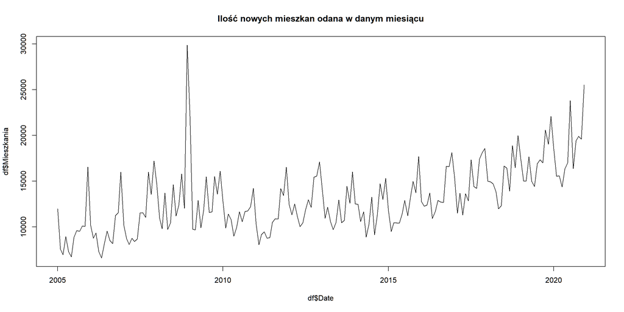

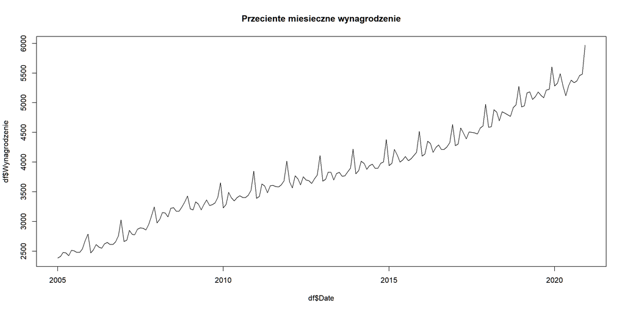

## Z wykresów widzimy, że mamy do czynienia z danymi o dużej sezonowości oraz szeregami potencjalnie niestacjonarnymi z trendem.

### Żeby doprowadzić wykres do stacjonarność oraz nie stracić na możliwości interpretacji wyników przeliczamy procentową zmianę miesiąc do miesiąca.

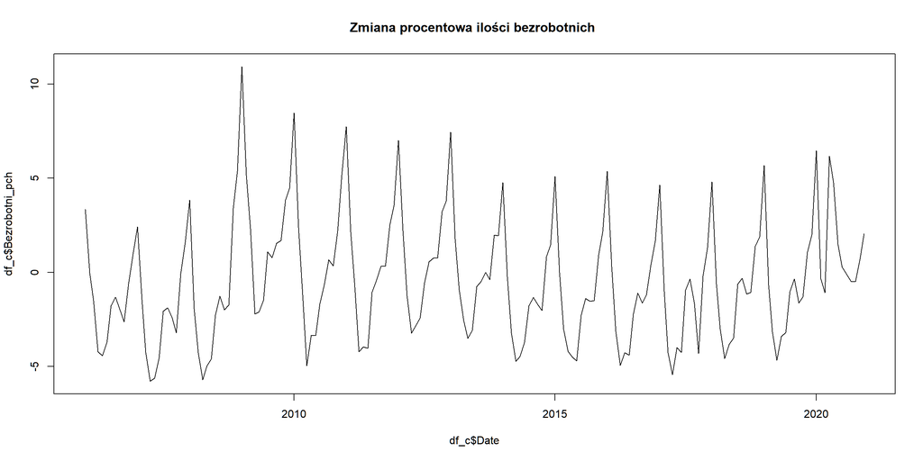

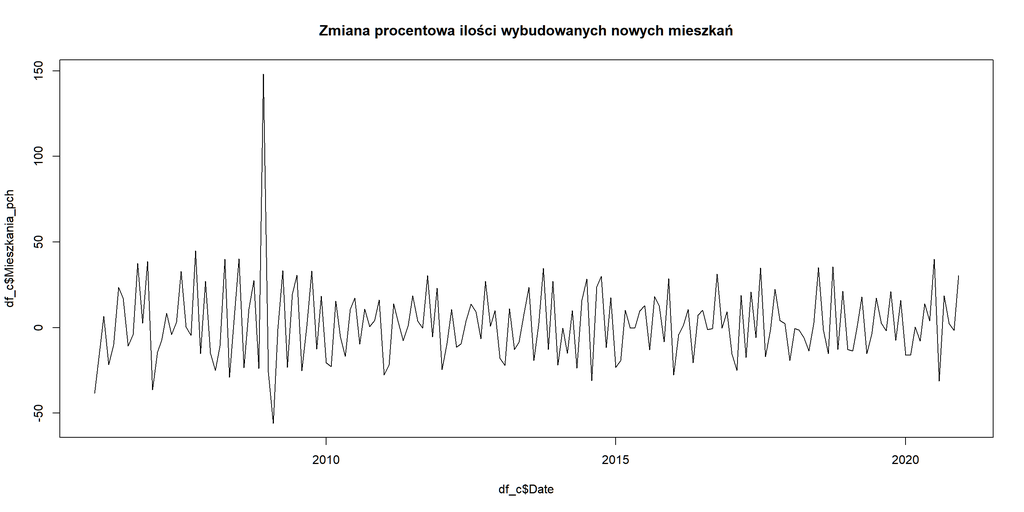

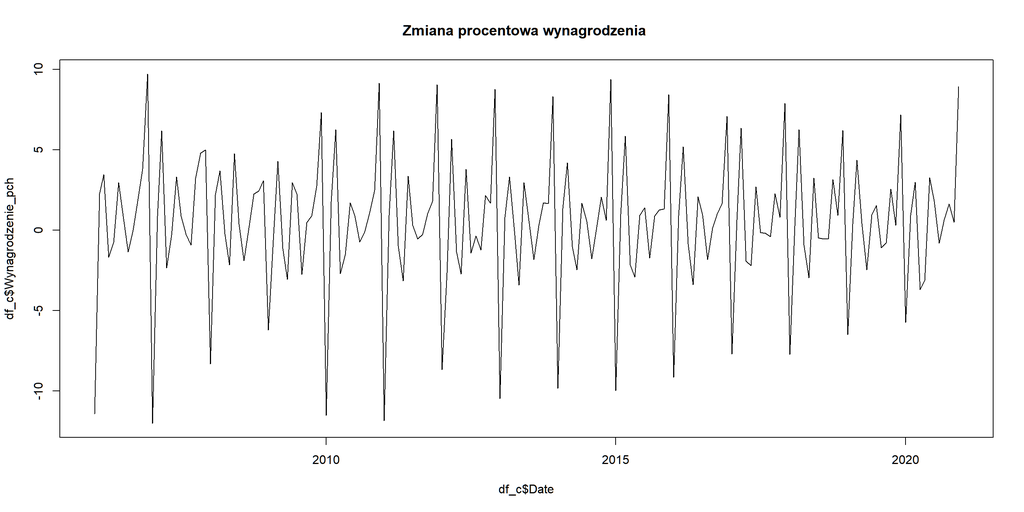

### Możemy zauważyć wpływ kryzysu z roku 2008 na ilość wybudowanych mieszkań.

### widzimy stanowcze zaburzenie sezonowości w ilości osób bezrobotnych w roku 2020 z powodu pandemii, podobne zaburzenie możemy zobaczyć na wykresie przeciętnego wynagrodzenia.

## Sprawdźmy korelacje między dwoma zmiennymi.

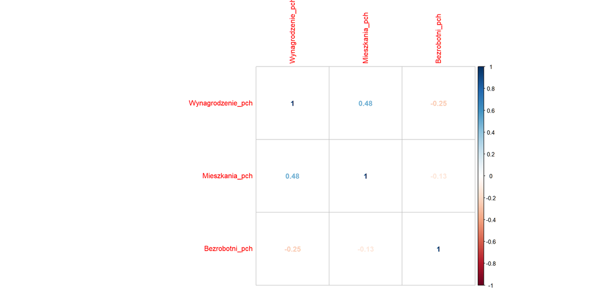

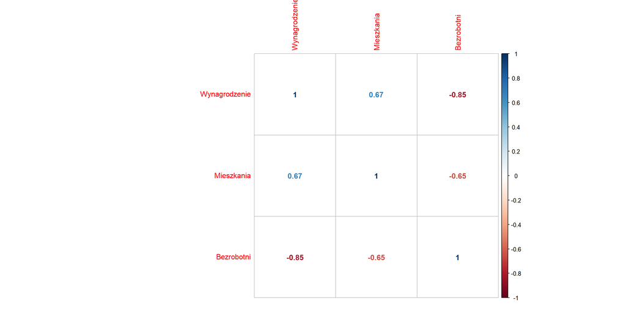

Obserwujemy spodziewane wyniki, wysoką ujemną korelację między wynagrodzeniem a ilością bezrobotnych. Pozytywną korelację między wynagrodzeniem a ilością nowo oddanych mieszkań, co daje nam możliwość na wyjaśnianie jednią zmiennej drugą.

### Wnioski

Ze względu na wysoką korelację pomiędzy ilością bezrobotnych a wynagrodzeniem z dalszej analizy odrzucimy stopę bezrobocia i skupimy się na interakcji między przeciętnym wynagrodzeniem a ilością nowo wybudowanych mieszkań.

## Test ADF dla zmiany procentowej wynagrodzenia

```
##
##  Augmented Dickey-Fuller Test
##
## data:  df_c$Wynagrodzenie_pch
## Dickey-Fuller = -6.8606, Lag order = 5, p-value = 0.01
## alternative hypothesis: stationary
```

## Test ADF dla zmiany procentowej ilości nowych mieszkań.

```
##
##  Augmented Dickey-Fuller Test
##
## data:  df_c$Mieszkania_pch
## Dickey-Fuller = -7.1001, Lag order = 5, p-value = 0.01
## alternative hypothesis: stationary
```

### Każdy szczyt na periodogramie dla łatwości w odczytaniu i interpetacji ma przypisany do siebie odowiadjący mu okres(1/częstotliwość) zaokrąglony do dwóch miejsc po precinku.

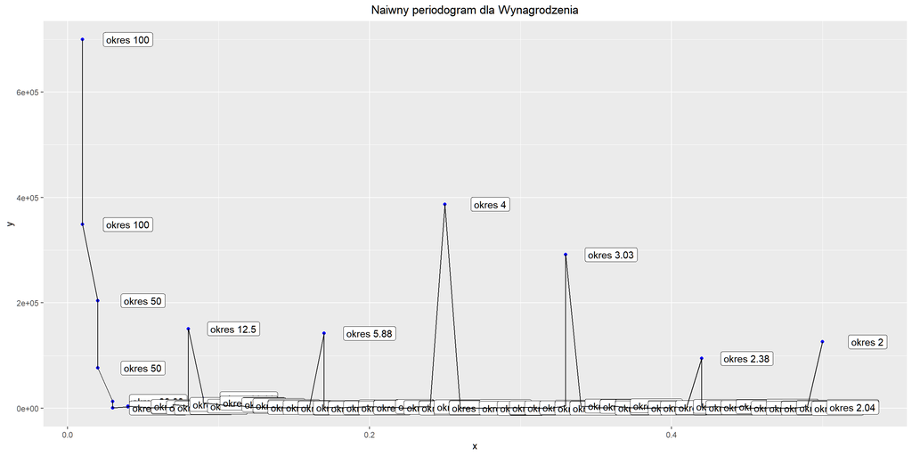

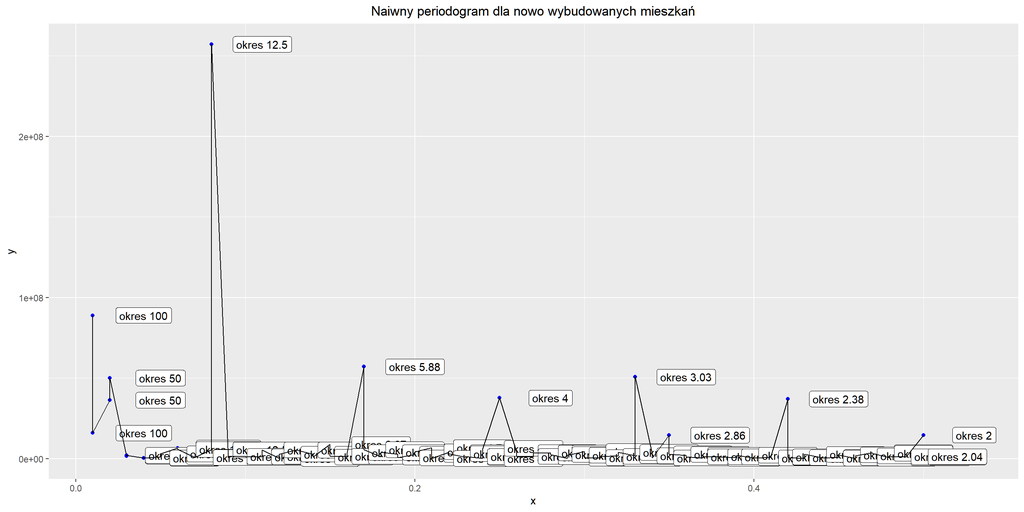

## W obu przypadkach widzimmy spike dla bardzo niskich częstoliwości, co sugeruje nam wystepowanie trendu. pracowanie na zmianach procentowych powinno wyeliminować ten problem.

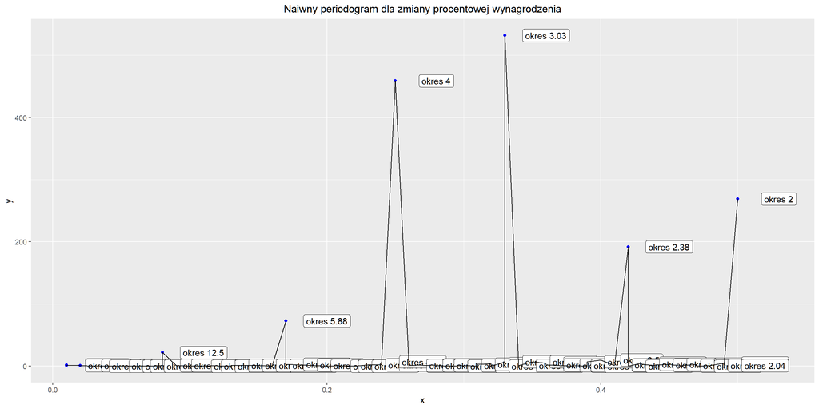

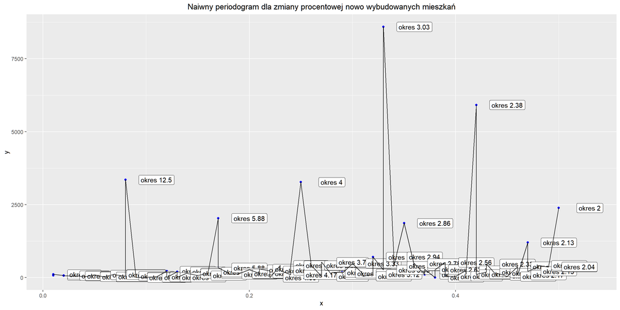

## Mamy bardzo ładne periodogramy naiwne.

### Widzimy wyraźnie okresy 12 miesięcy, połroczne, cztero miesieczne oraz kwartalne, glowny cykl powtarza się co kwartał

### wygładzanie średnią ruchomą

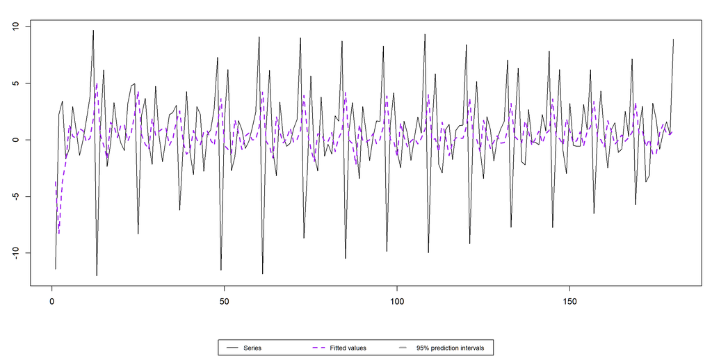

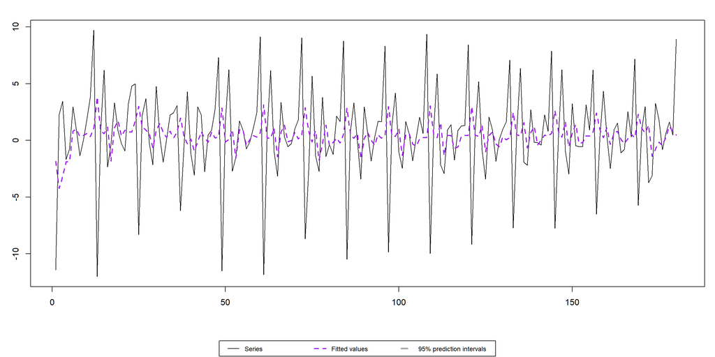

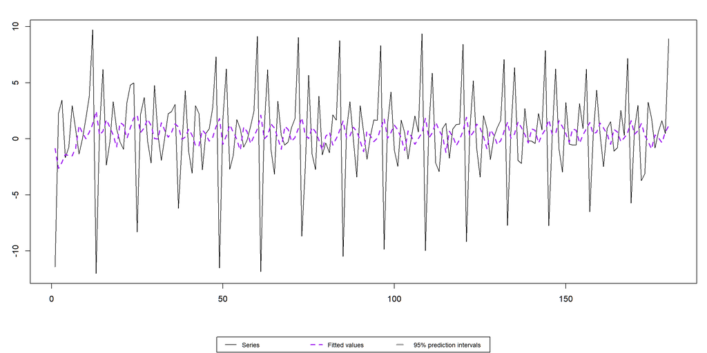

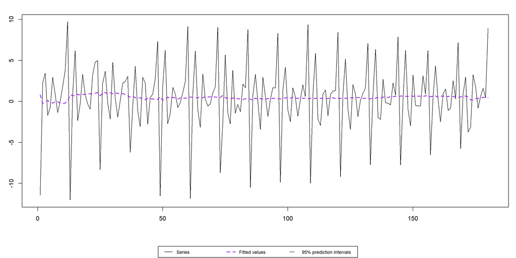

### Wykres został najlepiej wygładzony dla średniej równej 12

### Periodogram dla wynagrodzenia w naiwnej formie wyglądał na czysty

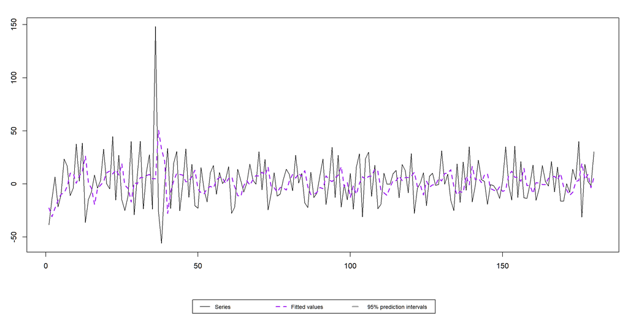

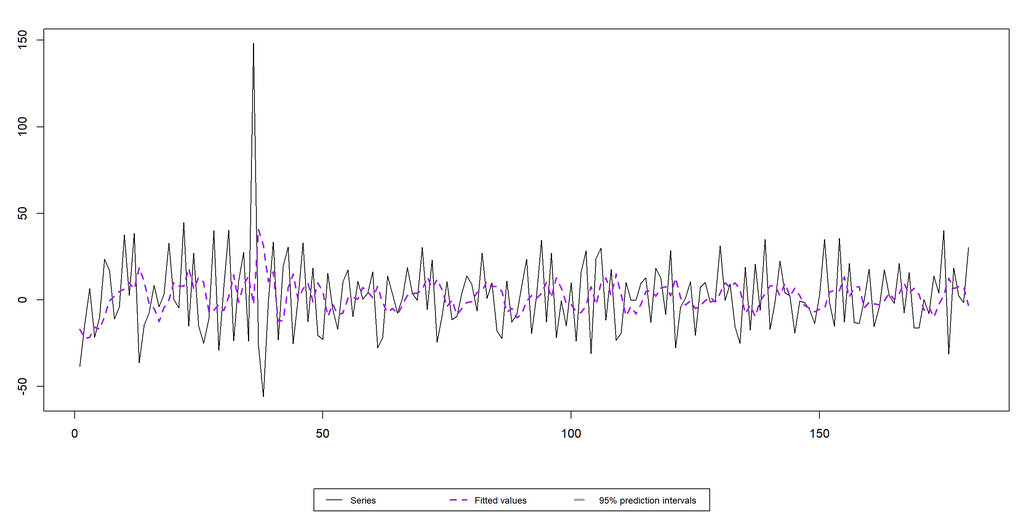

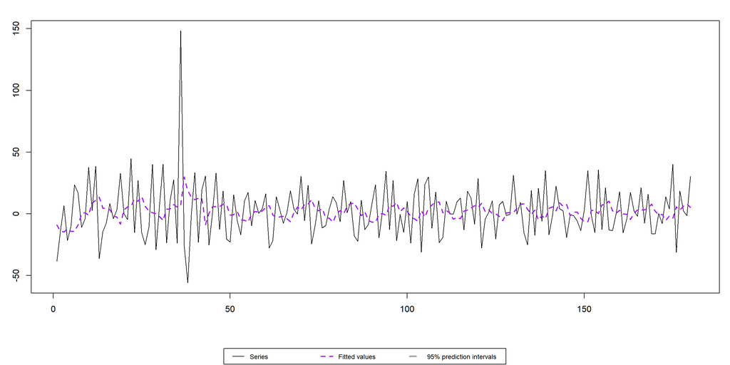

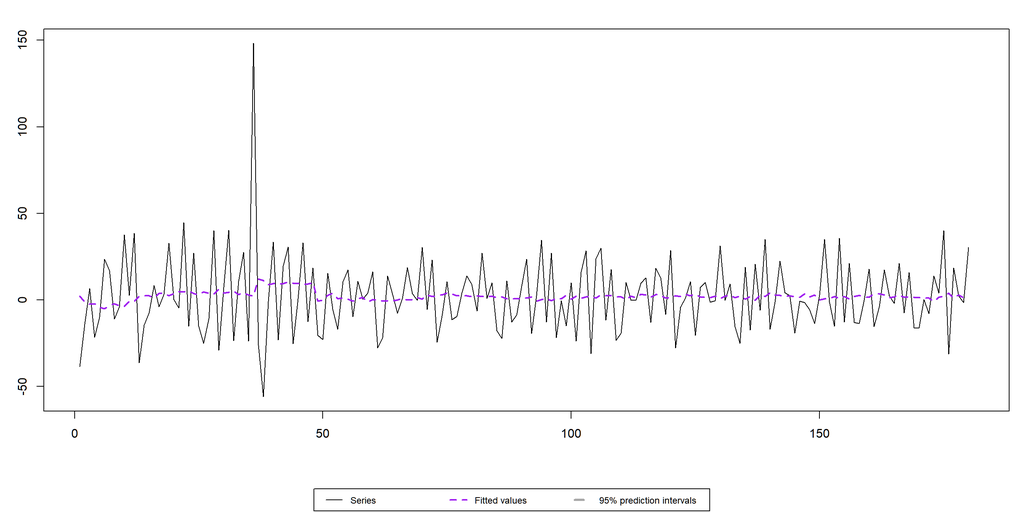

## Mieszkania również wykazują bardzo dobre wygładzenie za pomocą średniej ruchomej 12-miesięcznej.

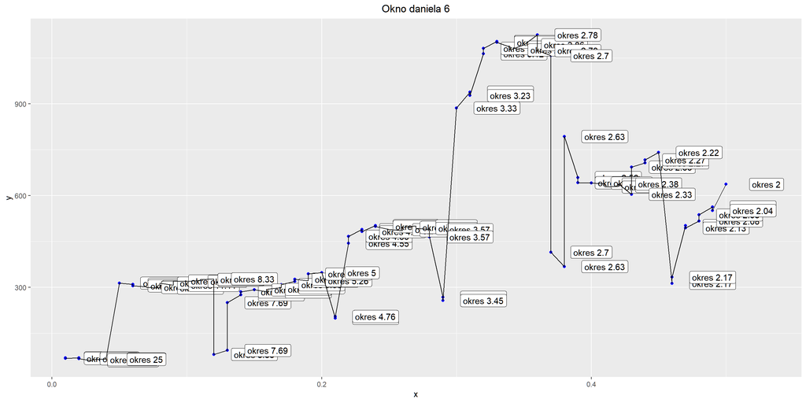

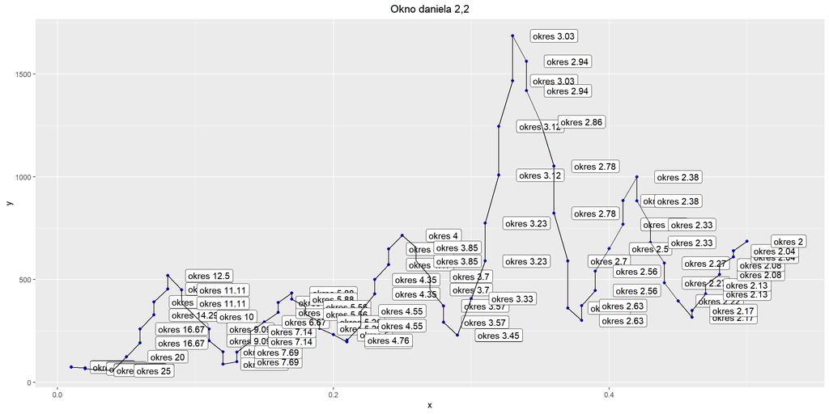

### Okno daniela nie daje rady wygładzić periodogramu

### próba wygładzenia metodą multitaper

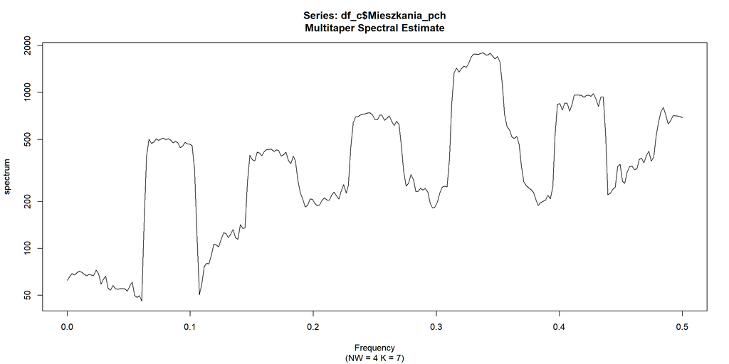

# Periodogram Welcha

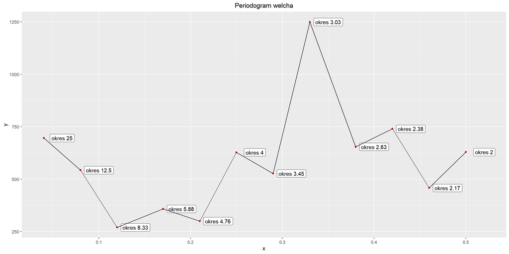

### Periodogram welcha osiąga maksimum dla okresu 3-miesięcznego, czyli kwartalnego, widzimy również okres roczny i okres dwuletni.

### odfiltrowanie cykli 3,4 oraz 12-miesięcznych

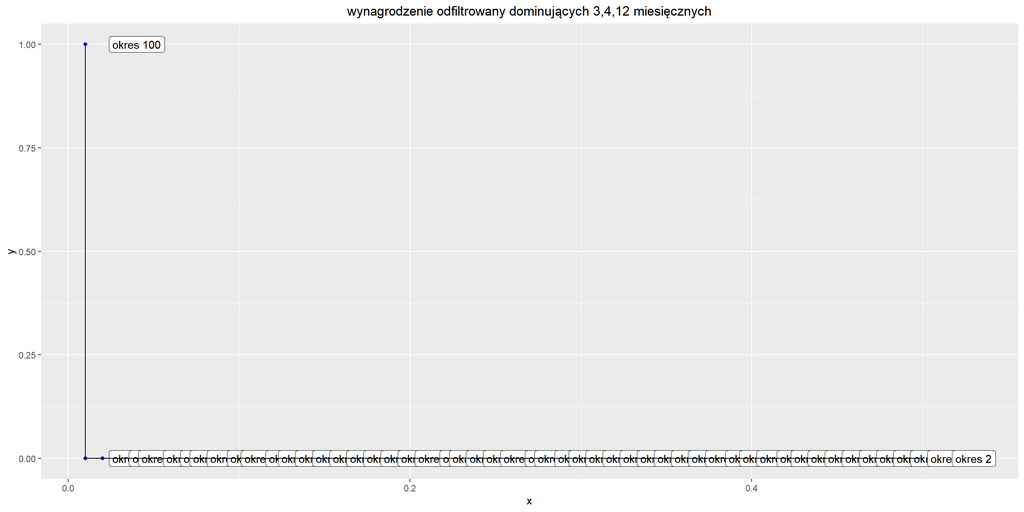

### Jesteśmy pewni występowania cyklów 3, 4 i 12-miesięcznego w zmianach

### wykonajmy tę samą procedurę dla mieszkań

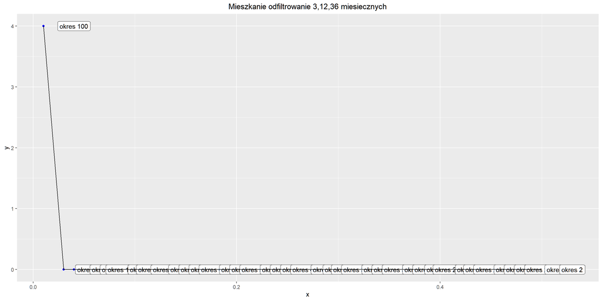

## odfiltrowane wykresy

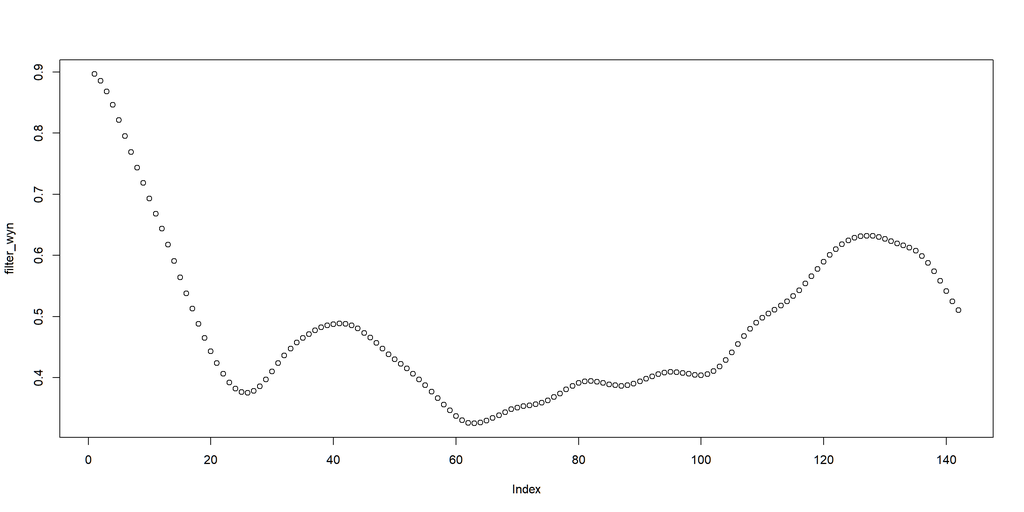

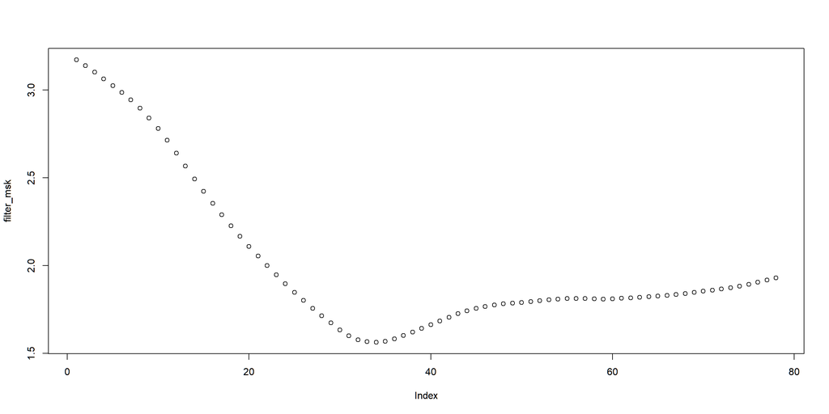

### Widzimy, że przyrost nowych mieszkań jest w miarę stały po bum w okolicach lat 2008, potem mamy w miarę stały przyrost na poziomie około 2%

### Wzrost przeciętnej pensji jest mniejszy, bo teraz utrzymuje się okolicy 0.5 % z zauważalnym spadkiem w 2008 roku oraz roku 2020

### Zobaczy dłużej terminowe zmiany biorąc zmianę w stosunku do analogicznego, poprzedniego okresu.

# Periodogramy dla zmian rok do roku

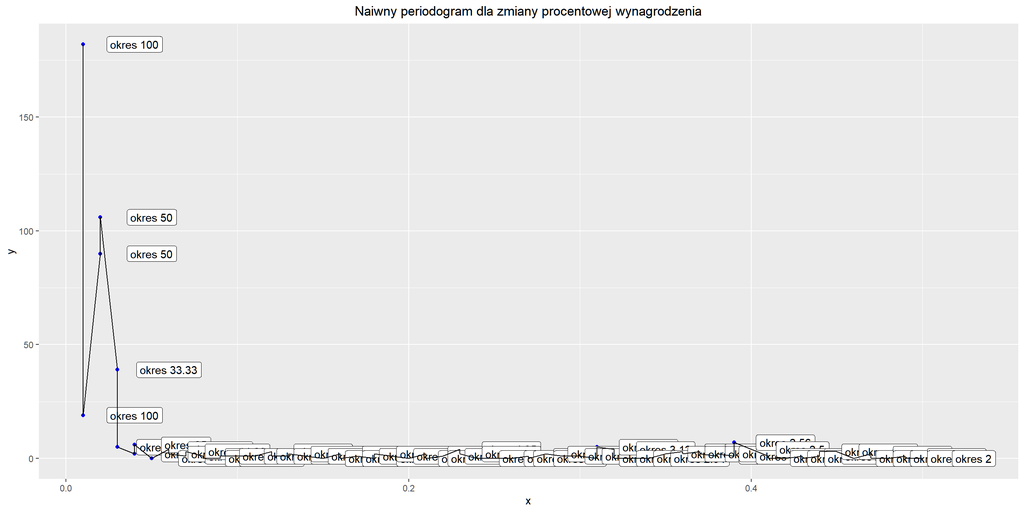

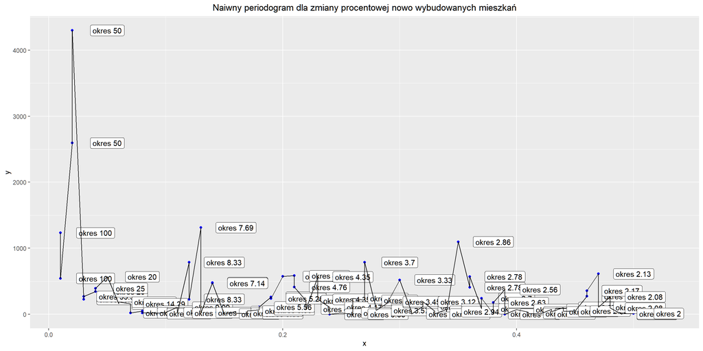